# EasyVisa Project

## Context:

Business communities in the United States are facing high demand for human resources, but one of the constant challenges is identifying and attracting the right talent, which is perhaps the most important element in remaining competitive. Companies in the United States look for hard-working, talented, and qualified individuals both locally as well as abroad.

The Immigration and Nationality Act (INA) of the US permits foreign workers to come to the United States to work on either a temporary or permanent basis. The act also protects US workers against adverse impacts on their wages or working conditions by ensuring US employers' compliance with statutory requirements when they hire foreign workers to fill workforce shortages. The immigration programs are administered by the Office of Foreign Labor Certification (OFLC).

OFLC processes job certification applications for employers seeking to bring foreign workers into the United States and grants certifications in those cases where employers can demonstrate that there are not sufficient US workers available to perform the work at wages that meet or exceed the wage paid for the occupation in the area of intended employment.

## Objective:

In FY 2016, the OFLC processed 775,979 employer applications for 1,699,957 positions for temporary and permanent labor certifications. This was a nine percent increase in the overall number of processed applications from the previous year. The process of reviewing every case is becoming a tedious task as the number of applicants is increasing every year.

The increasing number of applicants every year calls for a Machine Learning based solution that can help in shortlisting the candidates having higher chances of VISA approval. OFLC has hired your firm EasyVisa for data-driven solutions. You as a data scientist have to analyze the data provided and, with the help of a classification model:

- Facilitate the process of visa approvals.
- Recommend a suitable profile for the applicants for whom the visa should be certified or denied based on the drivers that significantly influence the case status.

## Data Description

The data contains the different attributes of the employee and the employer. The detailed data dictionary is given below.

- case_id: ID of each visa application
- continent: Information of continent the employee
- education_of_employee: Information of education of the employee
- has_job_experience: Does the employee has any job experience? Y= Yes; N = No
- requires_job_training: Does the employee require any job training? Y = Yes; N = No
- no_of_employees: Number of employees in the employer's company
- yr_of_estab: Year in which the employer's company was established
- region_of_employment: Information of foreign worker's intended region of employment in the US.
- prevailing_wage: Average wage paid to similarly employed workers in a specific occupation in the area of intended employment. The purpose of the prevailing wage is to ensure that the foreign worker is not underpaid compared to other workers offering the same or similar service in the same area of employment.
- unit_of_wage: Unit of prevailing wage. Values include Hourly, Weekly, Monthly, and Yearly.
- full_time_position: Is the position of work full-time? Y = Full Time Position; N = Part Time Position
- case_status: Flag indicating if the Visa was certified or denied

## Importing necessary libraries

```python
# Installing the libraries with the specified version.
!pip install numpy==1.25.2 pandas==2.0.3 scikit-learn==1.2.2 matplotlib==3.7.1 seaborn==0.13.1 xgboost==2.0.3
```

**Note**: *After running the above cell, kindly restart the notebook kernel and run all cells sequentially from the start again.*

```python
# Importing all the necessary libraries
import numpy as np
import pandas as pd

# for data visualization
import matplotlib.pyplot as plt
import seaborn as sns

sns.set()

# split the data into train and test
from sklearn.model_selection import train_test_split

# to build linear regression_model
from sklearn.linear_model import LinearRegression

# to check model performance
from sklearn.metrics import mean_absolute_error, mean_squared_error, r2_score

# to build linear regression_model using statsmodels
import statsmodels.api as sm

# to compute VIF
from statsmodels.stats.outliers_influence import variance_inflation_factor

import warnings

warnings.filterwarnings("ignore")

# Libraries to help with reading and manipulating data
import numpy as np
import pandas as pd

# Library to split data
from sklearn.model_selection import train_test_split

# libaries to help with data visualization
import matplotlib.pyplot as plt
import seaborn as sns

# Removes the limit for the number of displayed columns
pd.set_option("display.max_columns", None)
# Sets the limit for the number of displayed rows
pd.set_option("display.max_rows", 100)


# Libraries different ensemble classifiers
from sklearn.ensemble import (
    BaggingClassifier,
    RandomForestClassifier,
    AdaBoostClassifier,
    GradientBoostingClassifier,
    StackingClassifier,
)

from xgboost import XGBClassifier
from sklearn.tree import DecisionTreeClassifier

# Libraries to get different metric scores
from sklearn import metrics
from sklearn.metrics import (
    confusion_matrix,
    accuracy_score,
    precision_score,
    recall_score,
    f1_score,
)

# To tune different models
from sklearn.model_selection import GridSearchCV
```

## Importing Data

```python
#Mount the Drive
from google.colab import drive
drive.mount('/content/drive')

# Read in the data set.
visa = pd.read_csv('/content/drive/MyDrive/EasyVisa.csv')

data=visa.copy()
```

## Data Overview

- Observations will be at the end of this section.
- Sanity checks

```python
data.head()
```

|  | case_id | continent | education_of_employee | has_job_experience | requires_job_training | no_of_employees | yr_of_estab | region_of_employment | prevailing_wage | unit_of_wage | full_time_position | case_status |
| --- | --- | --- | --- | --- | --- | --- | --- | --- | --- | --- | --- | --- |
| 0 | EZYV01 | Asia | High School | N | N | 14513 | 2007 | West | 592.2029 | Hour | Y | Denied |
| 1 | EZYV02 | Asia | Master's | Y | N | 2412 | 2002 | Northeast | 83425.6500 | Year | Y | Certified |
| 2 | EZYV03 | Asia | Bachelor's | N | Y | 44444 | 2008 | West | 122996.8600 | Year | Y | Denied |
| 3 | EZYV04 | Asia | Bachelor's | N | N | 98 | 1897 | West | 83434.0300 | Year | Y | Denied |
| 4 | EZYV05 | Africa | Master's | Y | N | 1082 | 2005 | South | 149907.3900 | Year | Y | Certified |

```python
data.tail()
```

|  | case_id | continent | education_of_employee | has_job_experience | requires_job_training | no_of_employees | yr_of_estab | region_of_employment | prevailing_wage | unit_of_wage | full_time_position | case_status |
| --- | --- | --- | --- | --- | --- | --- | --- | --- | --- | --- | --- | --- |
| 25475 | EZYV25476 | Asia | Bachelor's | Y | Y | 2601 | 2008 | South | 77092.57 | Year | Y | Certified |
| 25476 | EZYV25477 | Asia | High School | Y | N | 3274 | 2006 | Northeast | 279174.79 | Year | Y | Certified |
| 25477 | EZYV25478 | Asia | Master's | Y | N | 1121 | 1910 | South | 146298.85 | Year | N | Certified |
| 25478 | EZYV25479 | Asia | Master's | Y | Y | 1918 | 1887 | West | 86154.77 | Year | Y | Certified |
| 25479 | EZYV25480 | Asia | Bachelor's | Y | N | 3195 | 1960 | Midwest | 70876.91 | Year | Y | Certified |

```python
data.shape
```

```
(25480, 12)
```

```python
data.info()
```

```
<class 'pandas.core.frame.DataFrame'>
RangeIndex: 25480 entries, 0 to 25479
Data columns (total 12 columns):
 #   Column                 Non-Null Count  Dtype
---  ------                 --------------  -----
 0   case_id                25480 non-null  object
 1   continent              25480 non-null  object
 2   education_of_employee  25480 non-null  object
 3   has_job_experience     25480 non-null  object
 4   requires_job_training  25480 non-null  object
 5   no_of_employees        25480 non-null  int64
 6   yr_of_estab            25480 non-null  int64
 7   region_of_employment   25480 non-null  object
 8   prevailing_wage        25480 non-null  float64
 9   unit_of_wage           25480 non-null  object
 10  full_time_position     25480 non-null  object
 11  case_status            25480 non-null  object
dtypes: float64(1), int64(2), object(9)
memory usage: 2.3+ MB
```

```python
data.describe()
```

|  | no_of_employees | yr_of_estab | prevailing_wage |
| --- | --- | --- | --- |
| count | 25480.000000 | 25480.000000 | 25480.000000 |
| mean | 5667.043210 | 1979.409929 | 74455.814592 |
| std | 22877.928848 | 42.366929 | 52815.942327 |
| min | -26.000000 | 1800.000000 | 2.136700 |
| 25% | 1022.000000 | 1976.000000 | 34015.480000 |
| 50% | 2109.000000 | 1997.000000 | 70308.210000 |
| 75% | 3504.000000 | 2005.000000 | 107735.512500 |
| max | 602069.000000 | 2016.000000 | 319210.270000 |

```python
duplicate_rows = data[data.duplicated()]
print("Duplicate Rows:")
```

```
Duplicate Rows:
```

```python
missing_values = data.isna().sum()
print("Missing Values:")
print(missing_values)
```

```
Missing Values:
case_id                  0
continent                0
education_of_employee    0
has_job_experience       0
requires_job_training    0
no_of_employees          0
yr_of_estab              0
region_of_employment     0
prevailing_wage          0
unit_of_wage             0
full_time_position       0
case_status              0
dtype: int64
```

```python
#Making a fresh copy to work with :)

df= data.copy
```

Data Overview Obersvations:

- This data will not be too difficult to clean up considering we have no missing values or duplicate records.
- However, when we check the statistical summary previously we see some negative numbers for the number of employees column so we must correct those numbers, we'll just use the absolute values for the same numbers.

## Exploratory Data Analysis (EDA)

- EDA is an important part of any project involving data.
- It is important to investigate and understand the data better before building a model with it.
- A few questions have been mentioned below which will help you approach the analysis in the right manner and generate insights from the data.
- A thorough analysis of the data, in addition to the questions mentioned below, should be done.

### Data Manipulation and Cleaning

```python
#Removing the negative values in number of employee Columns
negativeEmployeeNumbers = data[data['no_of_employees'] < 0].index
print(negativeEmployeeNumbers)
data["no_of_employees"] = abs(data["no_of_employees"])
```

```
Index([  245,   378,   832,  2918,  6439,  6634,  7224,  7281,  7318,  7761,
        9872, 11493, 13471, 14022, 14146, 14726, 15600, 15859, 16157, 16883,
       17006, 17655, 17844, 17983, 20815, 20984, 21255, 21760, 21944, 22084,
       22388, 23186, 23476],
      dtype='int64')
```

```python
# Making a list of all catrgorical variables
cat_col = list(data.select_dtypes("object").columns)

# Printing number of count of each unique value in each column
for column in cat_col:
    print(data[column].value_counts())
    print("-" * 50)
```

```
case_id
EZYV01       1
EZYV16995    1
EZYV16993    1
EZYV16992    1
EZYV16991    1
            ..
EZYV8492     1
EZYV8491     1
EZYV8490     1
EZYV8489     1
EZYV25480    1
Name: count, Length: 25480, dtype: int64
--------------------------------------------------
continent
Asia             16861
Europe            3732
North America     3292
South America      852
Africa             551
Oceania            192
Name: count, dtype: int64
--------------------------------------------------
education_of_employee
Bachelor's     10234
Master's        9634
High School     3420
Doctorate       2192
Name: count, dtype: int64
--------------------------------------------------
has_job_experience
Y    14802
N    10678
Name: count, dtype: int64
--------------------------------------------------
requires_job_training
N    22525
Y     2955
Name: count, dtype: int64
--------------------------------------------------
```

[output cut: 10 more lines]

```
Hour      2157
Week       272
Month       89
Name: count, dtype: int64
--------------------------------------------------
full_time_position
Y    22773
N     2707
Name: count, dtype: int64
--------------------------------------------------
case_status
Certified    17018
Denied        8462
Name: count, dtype: int64
--------------------------------------------------
```

```python
# checking the number of unique values
data["case_id"].nunique() ## Complete the code to check unique values in the mentioned column
```

```
25480
```

```python
data.drop(["case_id"], axis=1, inplace=True) ## Complete the code to drop 'case_id' column from the data
```

Observations:

### Univariate Data Analysis

#### a) Continent

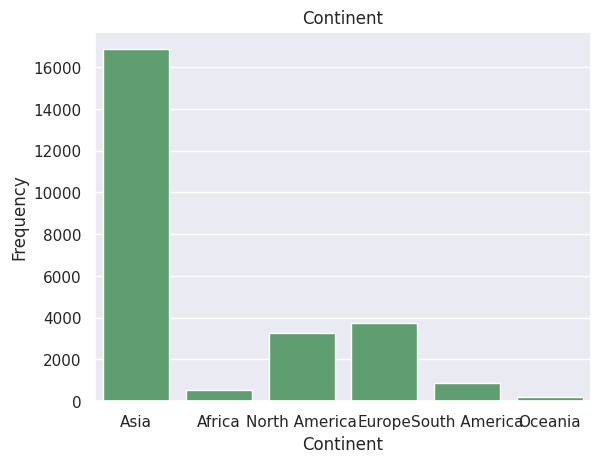

```
Stats for the Continent column
--------------------------------------------------
```

```
count     25480
unique        6
top        Asia
freq      16861
Name: continent, dtype: object
```

```python
#Plot the data in the Group column
plt.title("Continent")
plt.xlabel('Continent')
plt.ylabel('Frequency')
sns.countplot(data=data, x='continent', color='g')
plt.show()

print('\n')
print('Stats for the Continent column')
print('-'*50)
data['continent'].describe()
```

Observations:

```
*Clearly, we see Asia has a lead of at least 4 times that of the other continents in regards to cases for employee visa requests.
```

#### b) Employee Education

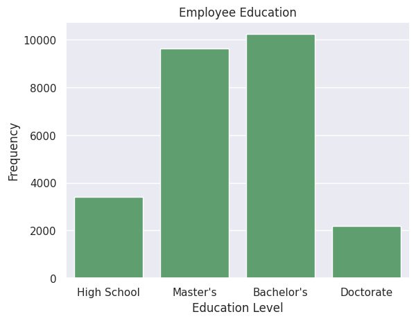

```
Stats for the Employee Education column
--------------------------------------------------
```

```
count          25480
unique             4
top       Bachelor's
freq           10234
Name: education_of_employee, dtype: object
```

```python
#Plot the data in the Group column
plt.title("Employee Education")
plt.xlabel('Education Level')
plt.ylabel('Frequency')
sns.countplot(data=data, x='education_of_employee', color='g')
plt.show()

print('\n')
print('Stats for the Employee Education column')
print('-'*50)
data['education_of_employee'].describe()
```

Observations:

```
*Most cases come with a Masters or a Bachelors. That is to be expected since most job that might offer a visa sponsorship are going to require some sort of specified training or education regardless.
```

#### c) Has Job Experience

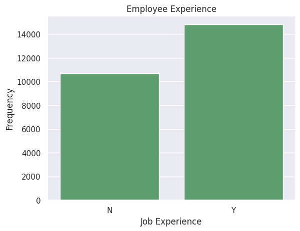

```
Stats for the Job Experience column
--------------------------------------------------
```

```
count     25480
unique        2
top           Y
freq      14802
Name: has_job_experience, dtype: object
```

```python
#Plot the data in the Group column
plt.title("Employee Experience")
plt.xlabel('Job Experience')
plt.ylabel('Frequency')
sns.countplot(data=data, x='has_job_experience', color='g')
plt.show()

print('\n')
print('Stats for the Job Experience column')
print('-'*50)
data['has_job_experience'].describe()
```

Observations:

```
*The majority of people already have some job experience which will likely help their case.
```

#### d) Requires Job Training

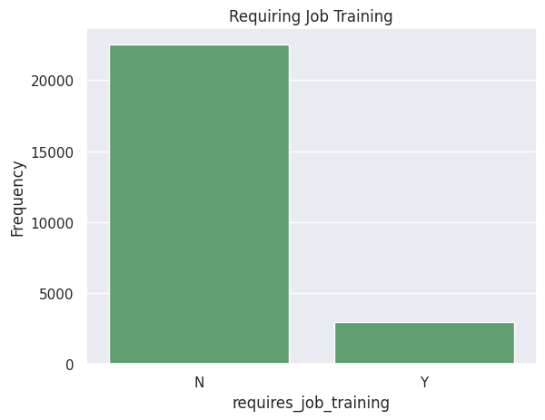

```
Stats for the Requires Job Training column
--------------------------------------------------
```

```
count     25480
unique        2
top           N
freq      22525
Name: requires_job_training, dtype: object
```

```python
#Plot the data in the Group column
plt.title('Requiring Job Training')
plt.xlabel('requires_job_training')
plt.ylabel('Frequency')
sns.countplot(data=data, x='requires_job_training', color='g')
plt.show()

print('\n')
print('Stats for the Requires Job Training column')
print('-'*50)
data['requires_job_training'].describe()
```

Observations:

[output not shown]

#### e) Number of Employees

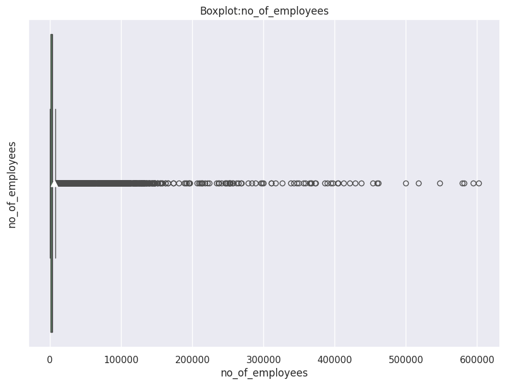

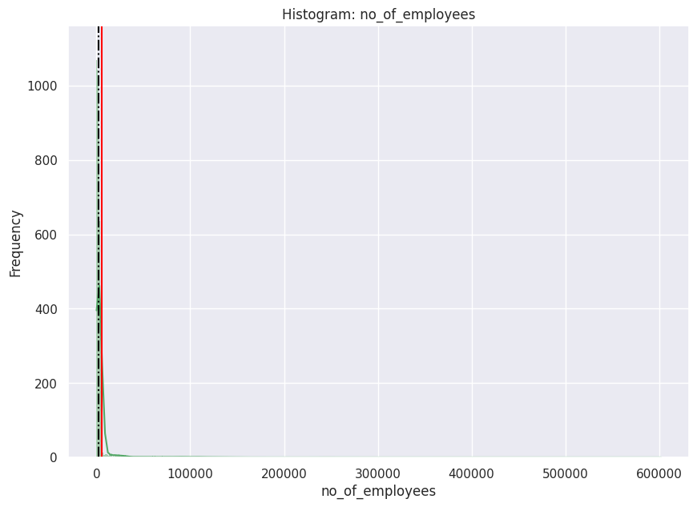

```python
mean_value = np.mean(data['no_of_employees'])
median_value = np.median(data['no_of_employees'])


plt.figure(figsize=(10,7))
plt.title('Boxplot:no_of_employees')
plt.ylabel('no_of_employees')
sns.boxplot(data = data, x='no_of_employees', color='g')
plt.scatter(mean_value, 0, color='white', marker='^', s=60, zorder=10)
plt.show()


plt.figure(figsize=(10,7))
plt.title("Histogram: no_of_employees")
plt.xlabel('no_of_employees')
plt.ylabel('Frequency')
sns.histplot(data=data, x='no_of_employees', color='g', kde=True)
plt.axvline(x=mean_value, color='red', linestyle='-', label='Mean')
plt.axvline(x=median_value, color='black', linestyle='-.', label='Median')
plt.show()
```

Observations:

```
*Some of these companies are clearly global considering how many employees they have. They would certainly require visas to continue in business operations if they need their employees to be able to travel.
```

#### f) Year of Establishment

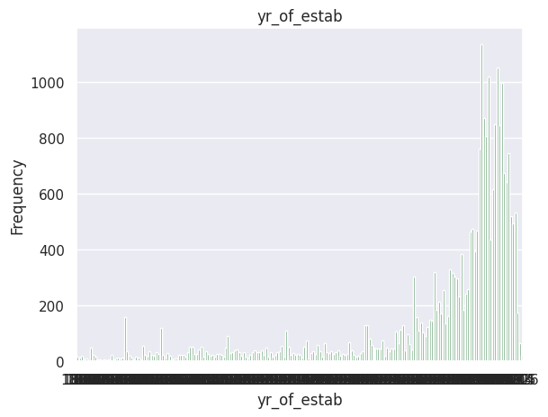

```
Stats for the yr_of_estab column
--------------------------------------------------
```

```
count    25480.000000
mean      1979.409929
std         42.366929
min       1800.000000
25%       1976.000000
50%       1997.000000
75%       2005.000000
max       2016.000000
Name: yr_of_estab, dtype: float64
```

```python
#Plot the data in the Group column
plt.title('yr_of_estab')
plt.xlabel('yr_of_estab')
plt.ylabel('Frequency')
sns.countplot(data=data, x='yr_of_estab', color='g')

plt.show()

print('\n')
print('Stats for the yr_of_estab column')
print('-'*50)
data['yr_of_estab'].describe()
```

Observations:

```
*We have some older comapnies that were founded in the 1800 still existing but the majority of the companies have been existing for the last 50 years or so.
```

#### g) Region of Employment

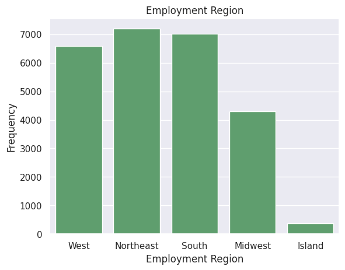

```
Stats for the region_of_employment column
--------------------------------------------------
```

```
count         25480
unique            5
top       Northeast
freq           7195
Name: region_of_employment, dtype: object
```

```python
#Plot the data in the Group column
plt.title("Employment Region")
plt.xlabel('Employment Region')
plt.ylabel('Frequency')
sns.countplot(data=data, x='region_of_employment', color='g')
plt.show()

print('\n')
print('Stats for the region_of_employment column')
print('-'*50)
data['region_of_employment'].describe()
```

Observations:

[output not shown]

#### h) Prevailing Wage

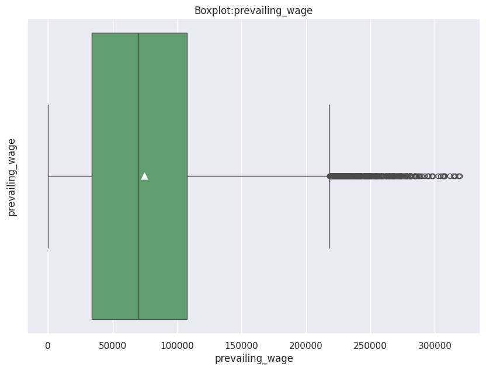

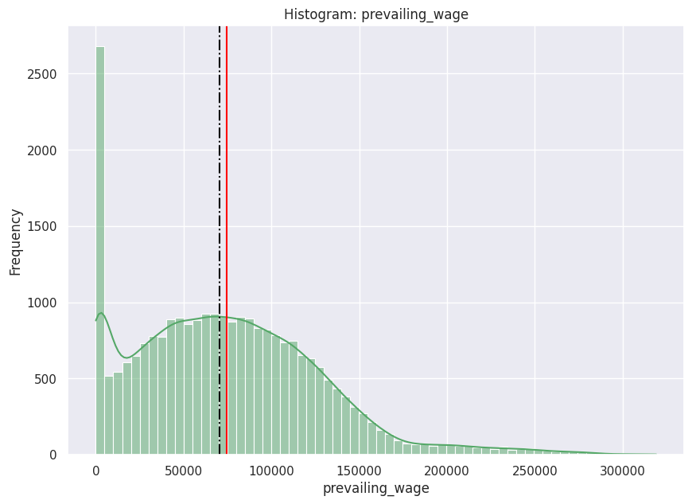

```
count     25480.000000
mean      74455.814592
std       52815.942327
min           2.136700
25%       34015.480000
50%       70308.210000
75%      107735.512500
max      319210.270000
Name: prevailing_wage, dtype: float64
```

```python
mean_value = np.mean(data['prevailing_wage'])
median_value = np.median(data['prevailing_wage'])


plt.figure(figsize=(10,7))
plt.title('Boxplot:prevailing_wage')
plt.ylabel('prevailing_wage')
sns.boxplot(data = data, x='prevailing_wage', color='g')
plt.scatter(mean_value, 0, color='white', marker='^', s=60, zorder=10)
plt.show()


plt.figure(figsize=(10,7))
plt.title("Histogram: prevailing_wage")
plt.xlabel('prevailing_wage')
plt.ylabel('Frequency')
sns.histplot(data=data, x='prevailing_wage', color='g', kde=True)
plt.axvline(x=mean_value, color='red', linestyle='-', label='Mean')
plt.axvline(x=median_value, color='black', linestyle='-.', label='Median')
plt.show()
data['prevailing_wage'].describe()
```

Observations:

```
*Most jobs that are requesting visas are for jobs earning just below $75000
```

#### i) Unit of Wage

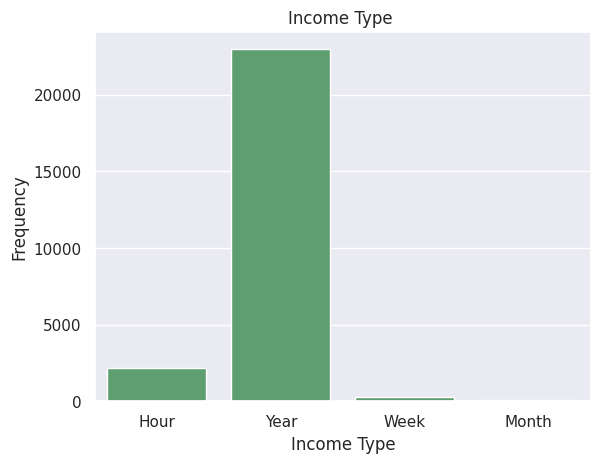

```
Stats for the unit_of_wage column
--------------------------------------------------
```

```
count     25480
unique        4
top        Year
freq      22962
Name: unit_of_wage, dtype: object
```

```python
#Plot the data in the Group column
plt.title("Income Type ")
plt.xlabel('Income Type')
plt.ylabel('Frequency')
sns.countplot(data=data, x='unit_of_wage', color='g')
plt.show()

print('\n')
print('Stats for the unit_of_wage column')
print('-'*50)
data['unit_of_wage'].describe()
```

Observations:

```
*The overwhelming majority of these jobs are salaried jobs.
```

#### j) Full Time or Part Time Position

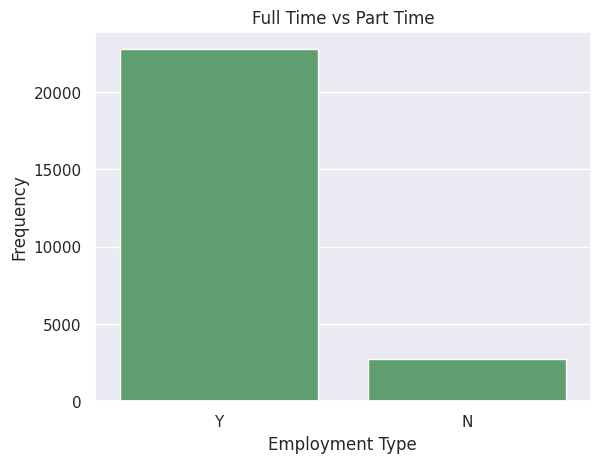

```
Stats for the full_time_position column
--------------------------------------------------
```

```
count     25480
unique        2
top           Y
freq      22773
Name: full_time_position, dtype: object
```

```python
#Plot the data in the Group column
plt.title("Full Time vs Part Time")
plt.xlabel('Employment Type')
plt.ylabel('Frequency')
sns.countplot(data=data, x='full_time_position', color='g')
plt.show()

print('\n')
print('Stats for the full_time_position column')
print('-'*50)
data['full_time_position'].describe()
```

Observations:

```
* The majority of these jobs are for full time offers.
```

#### k) Approved or Denied Case Status

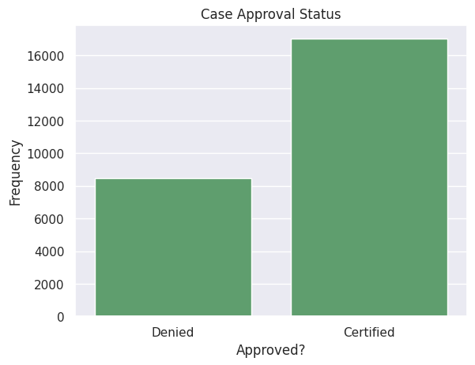

```
Stats for the case_status column
--------------------------------------------------
```

```
count         25480
unique            2
top       Certified
freq          17018
Name: case_status, dtype: object
```

```python
#Plot the data in the Group column
plt.title("Case Approval Status")
plt.xlabel('Approved?')
plt.ylabel('Frequency')
sns.countplot(data=data, x='case_status', color='g')
plt.show()

print('\n')
print('Stats for the case_status column')
print('-'*50)
data['case_status'].describe()
```

Observations:

```
* It seems like 66.78% of the cases will get approved. So there is a good change you could get approved given you have the qualifications and education required for the job.
```

### Bivariate Data Analysis

#### HeatMap Demo

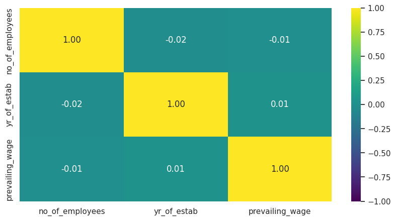

```python
cols_list = data.select_dtypes(include=np.number).columns.tolist()
plt.figure(figsize=(10, 5))
sns.heatmap(
    data[cols_list].corr(), annot=True, vmin=-1, vmax=1, fmt=".2f", cmap="viridis"
) ## Complete the code to find the correlation between the variableplt.show()
```

Observations:

```
* Since most columns are actually in object form the heat map doesn't show many details.
* However it is interesting to note that the prevailing wage and the number of employees per company case actually have a negative correlation.
```

#### functions for plotting

```python
### function to plot distributions wrt target


def distribution_plot_wrt_target(data, predictor, target):

    fig, axs = plt.subplots(2, 2, figsize=(12, 10))

    target_uniq = data[target].unique()

    axs[0, 0].set_title("Distribution of target for target=" + str(target_uniq[0]))
    sns.histplot(
        data=data[data[target] == target_uniq[0]],
        x=predictor,
        kde=True,
        ax=axs[0, 0],
        color="teal",
        stat="density",
    )

    axs[0, 1].set_title("Distribution of target for target=" + str(target_uniq[1]))
    sns.histplot(
        data=data[data[target] == target_uniq[1]],
        x=predictor,
        kde=True,
        ax=axs[0, 1],
        color="orange",
        stat="density",
    )

    axs[1, 0].set_title("Boxplot w.r.t target")
    sns.boxplot(data=data, x=target, y=predictor, ax=axs[1, 0], palette="gist_rainbow")

    axs[1, 1].set_title("Boxplot (without outliers) w.r.t target")
    sns.boxplot(
        data=data,
        x=target,
        y=predictor,
        ax=axs[1, 1],
        showfliers=False,
        palette="gist_rainbow",
    )

    plt.tight_layout()
    plt.show()
```

```python
def stacked_barplot(data, predictor, target):
    """
    Print the category counts and plot a stacked bar chart

    data: dataframe
    predictor: independent variable
    target: target variable
    """
    count = data[predictor].nunique()
    sorter = data[target].value_counts().index[-1]
    tab1 = pd.crosstab(data[predictor], data[target], margins=True).sort_values(
        by=sorter, ascending=False
    )
    print(tab1)
    print("-" * 120)
    tab = pd.crosstab(data[predictor], data[target], normalize="index").sort_values(
        by=sorter, ascending=False
    )
    tab.plot(kind="bar", stacked=True, figsize=(count + 5, 5))
    plt.legend(
        loc="lower left", frameon=False,
    )
    plt.legend(loc="upper left", bbox_to_anchor=(1, 1))
    plt.show()
```

#### a) Education versus Visa Certifcation.

```
case_status            Certified  Denied    All
education_of_employee
All                        17018    8462  25480
Bachelor's                  6367    3867  10234
High School                 1164    2256   3420
Master's                    7575    2059   9634
Doctorate                   1912     280   2192
------------------------------------------------------------------------------------------------------------------------
```

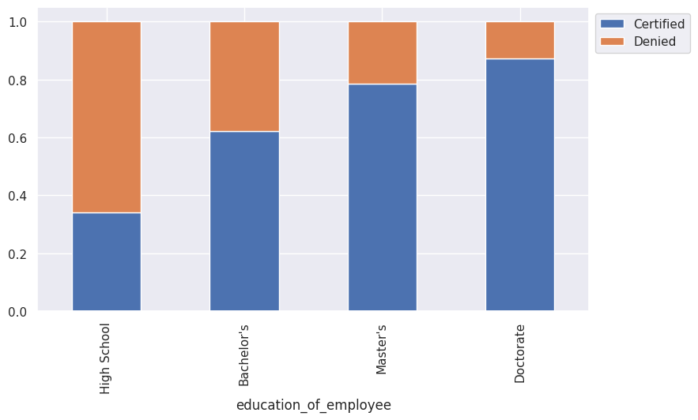

```python
stacked_barplot(data, "education_of_employee", "case_status")
```

Observations:

```
* We see a positive increase in approved visas the higher the level of education.
* So it does seem that the education does have a positive impact on the likelihood of success for the visa.
```

#### b) Location versus Education Level Diversity

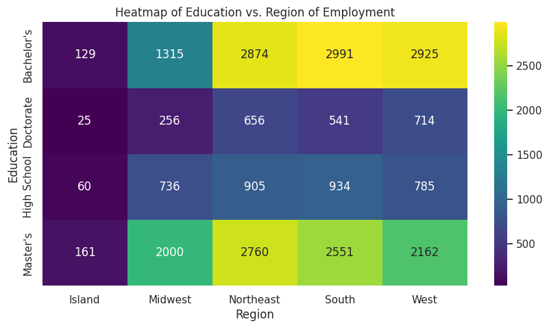

```python
plt.figure(figsize=(10, 5))
sns.heatmap(pd.crosstab(data['education_of_employee'], data['region_of_employment']),
    annot=True,
    fmt="g",
    cmap="viridis"
)

plt.ylabel("Education")
plt.xlabel("Region")
plt.title("Heatmap of Education vs. Region of Employment")
plt.show()
```

Observations:

[output not shown]

#### c) Region versus Visa Certifications

```
case_status           Certified  Denied    All
region_of_employment
All                       17018    8462  25480
Northeast                  4526    2669   7195
West                       4100    2486   6586
South                      4913    2104   7017
Midwest                    3253    1054   4307
Island                      226     149    375
------------------------------------------------------------------------------------------------------------------------
```

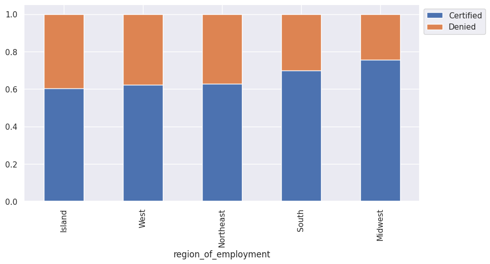

```python
stacked_barplot(data, "region_of_employment", "case_status")
```

Observations:

[output not shown]

#### d) Continents versus Visa Certications

```
case_status    Certified  Denied    All
continent
All                17018    8462  25480
Asia               11012    5849  16861
North America       2037    1255   3292
Europe              2957     775   3732
South America        493     359    852
Africa               397     154    551
Oceania              122      70    192
------------------------------------------------------------------------------------------------------------------------
```

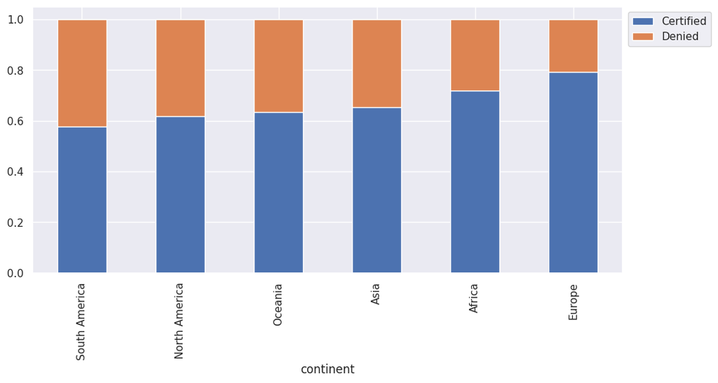

```python
stacked_barplot(data, "continent", "case_status")
```

Observations:

```
* People from European countries have a higher change of getting approved.
* Applicants from South America have a lower likelihood to gain approval.
```

#### e) Job Experience Versus Case Status

```
case_status         Certified  Denied    All
has_job_experience
All                     17018    8462  25480
N                        5994    4684  10678
Y                       11024    3778  14802
------------------------------------------------------------------------------------------------------------------------
```

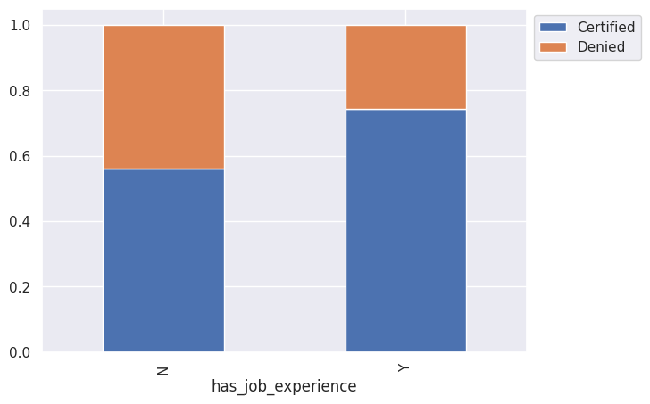

```python
stacked_barplot(data, "has_job_experience", "case_status")
```

Obervations:

```
* You have a higher chance of getting an approval if you have job experience.
```

#### f) Job Experience versus Requiring Job Training

```
requires_job_training      N     Y    All
has_job_experience
All                    22525  2955  25480
N                       8988  1690  10678
Y                      13537  1265  14802
------------------------------------------------------------------------------------------------------------------------
```

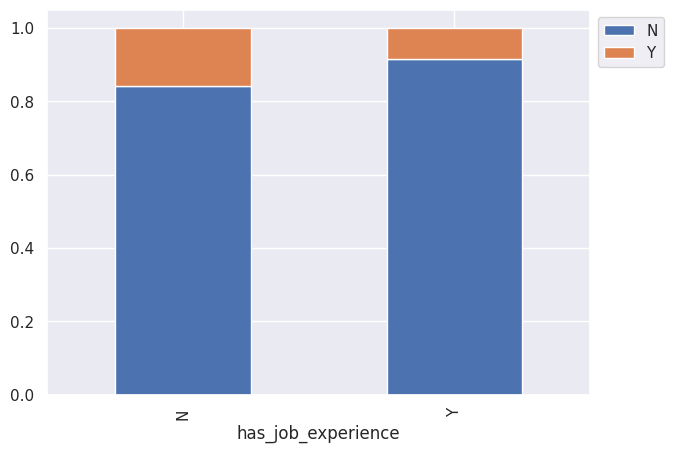

```python
stacked_barplot(data, "has_job_experience", "requires_job_training")
```

Observations:

[output not shown]

#### g) Unit of Wage versus Case Status

```
case_status   Certified  Denied    All
unit_of_wage
All               17018    8462  25480
Year              16047    6915  22962
Hour                747    1410   2157
Week                169     103    272
Month                55      34     89
------------------------------------------------------------------------------------------------------------------------
```

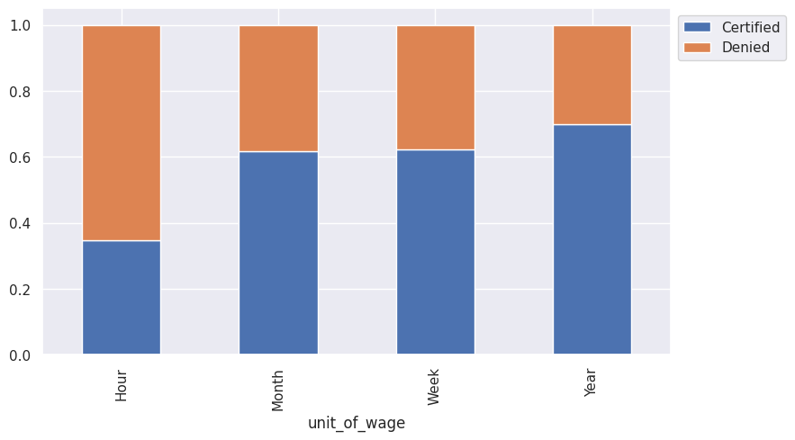

```python
stacked_barplot(data, "unit_of_wage", "case_status")
```

Observations:

```
* Salaries get approved at the highest rate.
* Hourlies get approved at the lowest rate.
```

#### h)Prevailing Wage vs Case Status

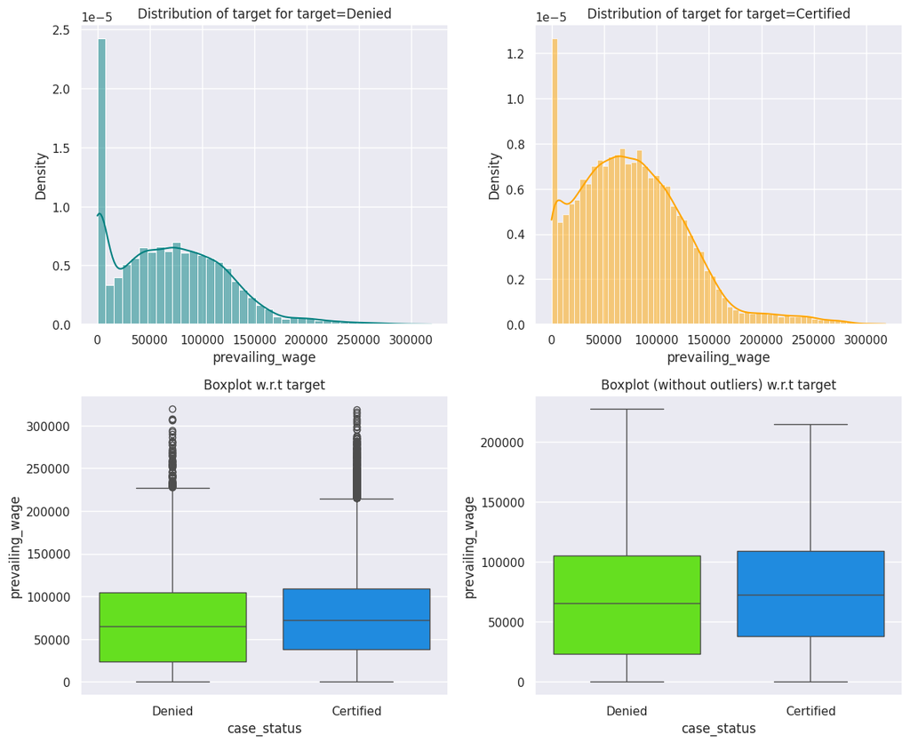

```python
distribution_plot_wrt_target(data, 'prevailing_wage', 'case_status')
```

Observations:

```
* The prevailing job income doesn't seem to change too too much between those approved or denied.
```

### Data Analysis Questions to Answer

**Leading Questions**:

1. Those with higher education may want to travel abroad for a well-paid job. Does education play a role in Visa certification?

```
  As we saw in our barplot above, you have a higher likelihood to get a visa if your education is greater than highschool level. But than also seems to increase with every education level you achieve- considering Doctorate applicants have a lower level of denial.
```

1. How does the visa status vary across different continents?

```
  Although the higher amount of applicants come from Asia, the lowest percentage of denial goes to European countries.
```

1. Experienced professionals might look abroad for opportunities to improve their lifestyles and career development. Does work experience influence visa status?

```
  As seen in our graphs above, you are more likely to get approved if you do have some relevent job experience.
```

1. In the United States, employees are paid at different intervals. Which pay unit is most likely to be certified for a visa?

```
  The pay most likely to get approved for a visa is an annual salary.
```

1. The US government has established a prevailing wage to protect local talent and foreign workers. How does the visa status change with the prevailing wage?

```
  It doesn't change much, the income offered would be about the same. So the applications arent approved or denied based on the potential income but more based on location, education and job experience.
```

## EDA

- It is a good idea to explore the data once again after manipulating it.

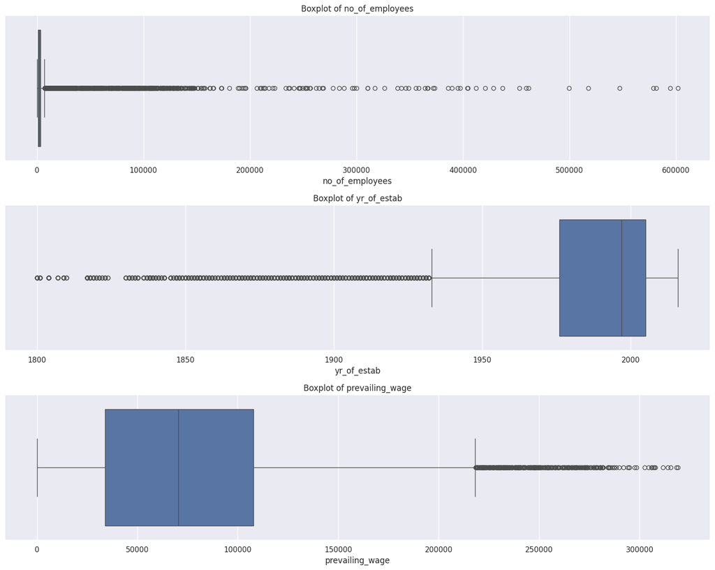

```python
# Select numeric columns
numeric_columns = data.select_dtypes(include=np.number).columns.tolist()

# Create a figure with a specified size
plt.figure(figsize=(15, 12))

# Loop over numeric columns and create a boxplot for each
for i, variable in enumerate(numeric_columns):
    plt.subplot(len(numeric_columns), 1, i + 1)
    sns.boxplot(x=data[variable])
    plt.title(f'Boxplot of {variable}')

# Adjust layout and display the plot
plt.tight_layout()
plt.show()
```

Preparing and splitting the data.

```python
import pandas as pd
from sklearn.model_selection import train_test_split

# Convert case_status to binary
data["case_status"] = data["case_status"].apply(lambda x: 1 if x == "Certified" else 0)

# Drop case_status from the data to create the feature matrix X
X = data.drop("case_status", axis=1)

# Define the target variable
Y = data["case_status"]

# Create dummy variables for categorical columns in X
X = pd.get_dummies(X, drop_first=True)

# Splitting data into train and test sets in a 70:30 ratio
X_train, X_test, y_train, y_test = train_test_split(X, Y, test_size=0.3, random_state=1, stratify=Y)

# Print the shapes of the training and test sets
print("Shape of Training set : ", X_train.shape)
print("Shape of test set : ", X_test.shape)

# Print the percentage of classes in the training set
print("Percentage of classes in training set:")
print(y_train.value_counts(normalize=True))

# Print the percentage of classes in the test set
print("Percentage of classes in test set:")
print(y_test.value_counts(normalize=True))
```

```
Shape of Training set :  (17836, 21)
Shape of test set :  (7644, 21)
Percentage of classes in training set:
case_status
1    0.667919
0    0.332081
Name: proportion, dtype: float64
Percentage of classes in test set:
case_status
1    0.667844
0    0.332156
Name: proportion, dtype: float64
```

Model Evaluation Criterion:

Create a function to comput the different metrics to check the performance of a sklearn classification model

```python
def model_performance_classification_sklearn(model, predictors, target):
    """
    Function to compute different metrics to check classification model performance

    model: classifier
    predictors: independent variables
    target: dependent variable
    """

    # predicting using the independent variables
    pred = model.predict(predictors)

    acc = accuracy_score(target, pred)  # to compute Accuracy
    recall = recall_score(target, pred)  # to compute Recall
    precision = precision_score(target, pred)  # to compute Precision
    f1 = f1_score(target, pred)  # to compute F1-score

    # creating a dataframe of metrics
    df_perf = pd.DataFrame(
        {"Accuracy": acc, "Recall": recall, "Precision": precision, "F1": f1,},
        index=[0],
    )

    return df_perf
```

```python
def confusion_matrix_sklearn(model, predictors, target):
    """
    To plot the confusion_matrix with percentages

    model: classifier
    predictors: independent variables
    target: dependent variable
    """
    y_pred = model.predict(predictors)
    cm = confusion_matrix(target, y_pred)
    labels = np.asarray(
        [
            ["{0:0.0f}".format(item) + "\n{0:.2%}".format(item / cm.flatten().sum())]
            for item in cm.flatten()
        ]
    ).reshape(2, 2)

    plt.figure(figsize=(6, 4))
    sns.heatmap(cm, annot=labels, fmt="")
    plt.ylabel("True label")
    plt.xlabel("Predicted label")
```

## Decision Tree -Model Build & Hyperparameter Tuning.

#### a) Decision tree model

```python
from sklearn.tree import DecisionTreeClassifier

# Define decision tree classifier with random state = 1
model = DecisionTreeClassifier(random_state=1)

# Fit decision tree classifier on the train data
model.fit(X_train, y_train)
```

```
DecisionTreeClassifier(random_state=1)
```

#### b)Training Set Model Performance

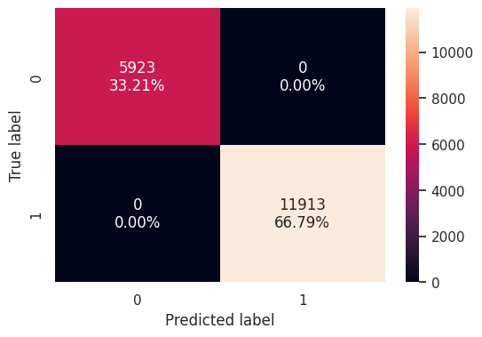

```python
confusion_matrix_sklearn(model, X_train, y_train)
decision_tree_perf_train = model_performance_classification_sklearn(model, X_train, y_train)
```

#### c) Test Set Model Performance

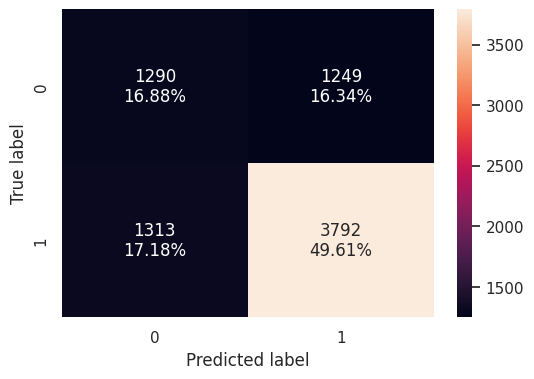

```python
confusion_matrix_sklearn(model, X_test, y_test)
decision_tree_perf_test = model_performance_classification_sklearn(model, X_test, y_test)
```

#### Hyperparameter Tuning

```python
# Choose the type of classifier.
dtree_estimator = DecisionTreeClassifier(class_weight="balanced", random_state=1)

# Grid of parameters to choose from
parameters = {
    "max_depth": np.arange(10, 20, 5),
    "min_samples_leaf": [3, 5],
    "max_leaf_nodes": [2, 3, 5],
    "min_impurity_decrease": [0.0001, 0.001],
}

# Type of scoring used to compare parameter combinations
scorer = metrics.make_scorer(metrics.f1_score)

# Run the grid search
grid_obj = GridSearchCV(dtree_estimator, parameters, scoring=scorer, n_jobs=-1)
grid_obj = grid_obj.fit(X_train, y_train)

# Set the clf to the best combination of parameters
dtree_estimator = grid_obj.best_estimator_

# Fit the best algorithm to the data.
dtree_estimator.fit(X_train, y_train)
```

```
DecisionTreeClassifier(class_weight='balanced', max_depth=10, max_leaf_nodes=2,
                       min_impurity_decrease=0.0001, min_samples_leaf=3,
                       random_state=1)
```

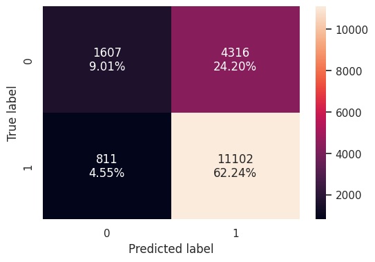

```python
confusion_matrix_sklearn(dtree_estimator, X_train, y_train)
```

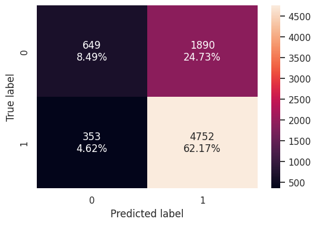

```python
confusion_matrix_sklearn(dtree_estimator, X_test, y_test)
```

```python
dtree_estimator_model_test_perf = model_performance_classification_sklearn(dtree_estimator, X_test, y_test)
```

## Building bagging and boosting models

### Bagging Classifier

```python
# Define bagging classifier
bagging_classifier = BaggingClassifier(random_state=1)

bagging_classifier.fit(X_train, y_train)
```

```
BaggingClassifier(random_state=1)
```

#### a) Bagging Classifier on Training Set

```python
bagging_classifier_model_train_perf = model_performance_classification_sklearn(bagging_classifier, X_train, y_train)
print(bagging_classifier_model_train_perf)
```

```
   Accuracy    Recall  Precision        F1
0  0.985198  0.985982    0.99181  0.988887
```

#### b) Bagging Classifier on Test Set

```python
bagging_classifier.fit(X_test, y_test)
```

```
BaggingClassifier(random_state=1)
```

```python
bagging_classifier_model_test_perf = model_performance_classification_sklearn(bagging_classifier,X_test, y_test)
```

[output not shown]

#### c) Hyperparameter tuning on the Bagging Classifier

```python
# Choose the type of classifier.
bagging_estimator_tuned = BaggingClassifier(random_state=1)

# Grid of parameters to choose from
parameters = {
    "max_samples": [0.7, 0.8],
    "max_features": [0.5,0.7,1],
    "n_estimators": np.arange(50,110,25),
}

# Type of scoring used to compare parameter combinations
acc_scorer = metrics.make_scorer(metrics.f1_score)

# Run the grid search with cv = 5
grid_obj = GridSearchCV(bagging_estimator_tuned, parameters, scoring=acc_scorer, cv=5, n_jobs=-1)

# Fit the grid_obj on train data
grid_obj = grid_obj.fit(X_train, y_train)

# Set the clf to the best combination of parameters
bagging_estimator_tuned = grid_obj.best_estimator_

# Fit the best algorithm to the data
bagging_estimator_tuned.fit(X_train, y_train)
```

```
BaggingClassifier(max_features=0.7, max_samples=0.7, n_estimators=100,
                  random_state=1)
```

#### d) Model Performance for Training Set

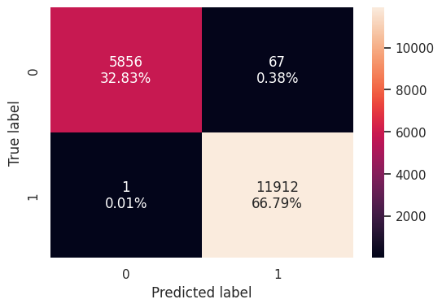

```python
confusion_matrix_sklearn(bagging_estimator_tuned, X_train, y_train)
```

```python
bagging_estimator_tuned_model_train_perf = model_performance_classification_sklearn(bagging_estimator_tuned, X_train, y_train)
bagging_estimator_tuned_model_train_perf
```

|  | Accuracy | Recall | Precision | F1 |
| --- | --- | --- | --- | --- |
| 0 | 0.996187 | 0.999916 | 0.994407 | 0.997154 |

#### e)Model Performance for the testing Set

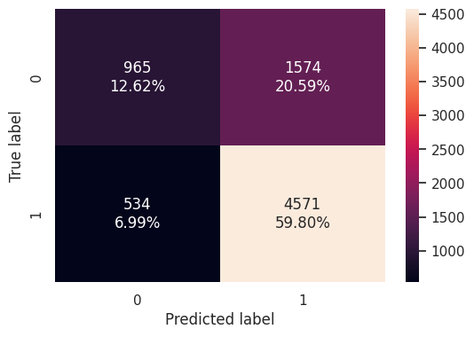

```python
confusion_matrix_sklearn(bagging_estimator_tuned, X_test, y_test)
```

```python
bagging_estimator_tuned_model_test_perf = model_performance_classification_sklearn(bagging_estimator_tuned, X_test, y_test)
bagging_estimator_tuned_model_test_perf
```

|  | Accuracy | Recall | Precision | F1 |
| --- | --- | --- | --- | --- |
| 0 | 0.724228 | 0.895397 | 0.743857 | 0.812622 |

### Random Forest

```python
from sklearn.ensemble import RandomForestClassifier

# Define the random forest estimator with random state = 1 and class_weight = balanced
rf_estimator = RandomForestClassifier(random_state=1, class_weight='balanced')

# Fit random forest on the train data
rf_estimator.fit(X_train, y_train)
```

```
RandomForestClassifier(class_weight='balanced', random_state=1)
```

#### a)Checking model performance on training set

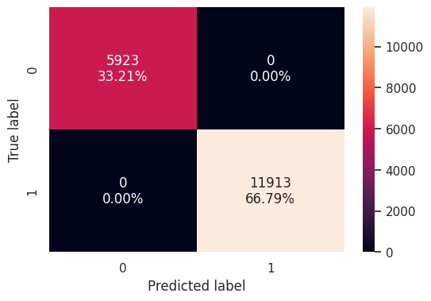

```python
confusion_matrix_sklearn(rf_estimator, X_train, y_train)
```

```python
rf_estimator_model_train_perf = model_performance_classification_sklearn(rf_estimator, X_train, y_train)
rf_estimator_model_train_perf
```

|  | Accuracy | Recall | Precision | F1 |
| --- | --- | --- | --- | --- |
| 0 | 1.0 | 1.0 | 1.0 | 1.0 |

#### b) Checking model performance on test set

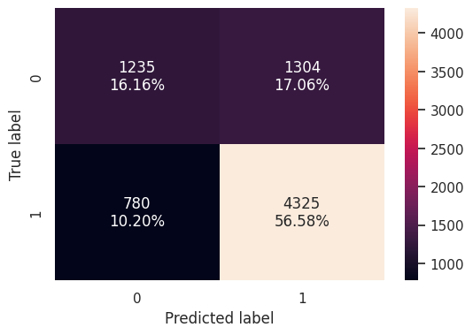

```python
confusion_matrix_sklearn(rf_estimator,  X_test, y_test)
```

```python
rf_estimator_model_test_perf = model_performance_classification_sklearn(rf_estimator, X_test, y_test)
rf_estimator_model_test_perf
```

|  | Accuracy | Recall | Precision | F1 |
| --- | --- | --- | --- | --- |
| 0 | 0.727368 | 0.847209 | 0.768343 | 0.805851 |

#### c)Hyperparameter Tuning - Random Forest

```python
from sklearn import metrics
from sklearn.ensemble import RandomForestClassifier

# Choose the type of classifier
rf_tuned = RandomForestClassifier(random_state=1, oob_score=True, bootstrap=True)

# Grid of parameters to choose from
parameters = {
    "max_depth": list(np.arange(5, 15, 5)),
    "max_features": ["sqrt", "log2"],
    "min_samples_split": [3, 5, 7],
    "n_estimators": np.arange(10, 40, 10),
}

# Type of scoring used to compare parameter combinations
acc_scorer = metrics.make_scorer(metrics.f1_score)

# Run the grid search with cv = 5 and n_jobs = -1
grid_obj = GridSearchCV(rf_tuned, parameters, scoring=acc_scorer, cv=5, n_jobs=-1)

# Fit the grid_obj on the train data
grid_obj = grid_obj.fit(X_train, y_train)

# Set the clf to the best combination of parameters
rf_tuned = grid_obj.best_estimator_

# Fit the best algorithm to the data
rf_tuned.fit(X_train, y_train)
```

```
RandomForestClassifier(max_depth=10, min_samples_split=7, n_estimators=20,
                       oob_score=True, random_state=1)
```

#### d) Checking model performance on training set

```python
rf_tuned_model_train_perf = model_performance_classification_sklearn(rf_tuned, X_train, y_train)
rf_tuned_model_train_perf
```

|  | Accuracy | Recall | Precision | F1 |
| --- | --- | --- | --- | --- |
| 0 | 0.769119 | 0.91866 | 0.776556 | 0.841652 |

#### e) Checking model performance on test set

```python
rf_tuned_model_test_perf = model_performance_classification_sklearn(rf_tuned, X_test, y_test)
rf_tuned_model_test_perf
```

|  | Accuracy | Recall | Precision | F1 |
| --- | --- | --- | --- | --- |
| 0 | 0.738095 | 0.898923 | 0.755391 | 0.82093 |